# BDA - Assignment 7

Anonymous

```r
library(tidyr)
library(rstan)
rstan_options(auto_write = TRUE)
options(mc.cores = parallel::detectCores())
library(loo)
```

```r
library(ggplot2)
library(gridExtra)
library(bayesplot)
theme_set(bayesplot::theme_default(base_family = "sans"))
library(shinystan)
source('stan_utility.R')
library(aaltobda)
SEED <- 48927 # set random seed for reproducability
```

## Fixing errors

The first crucial mistake is in line 10:

```r
real<upper=0> sigma;
```

The variance cannot be negative, therefor this line should be:

```r
real<lower=0> sigma;
```

Anoher mistake is in generated quantities. mu is a vector parameter, therefore defining ypred as a real value will make a syntax error.

```r
generated quantities {
  real ypred;
  ypred = normal_rng(mu , sigma);
}
```

The correct lines are as follows:

```r
generated quantities {
  real ypred;
  ypred = normal_rng(alpha + beta*xpred , sigma);
}
```

## Determination of $\tau$

The following lines will read the data. Data is summarized into a vectors of the years and the number of drownings in each year.

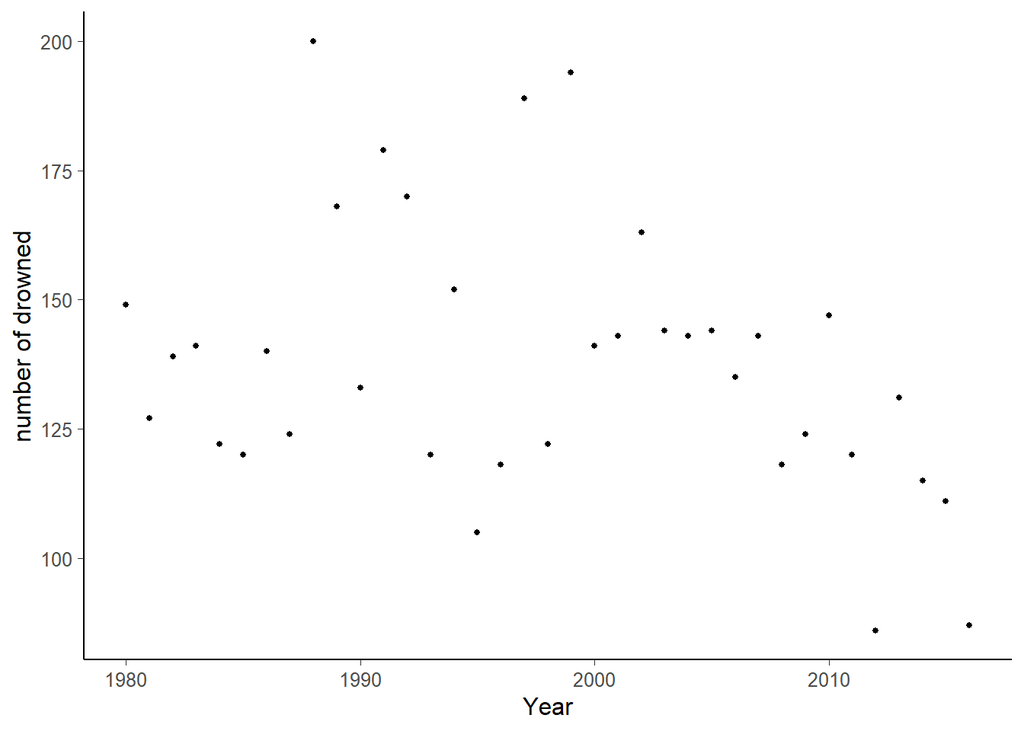

```r
data("drowning")
d_lin <- list(N = nrow(drowning),
              x = drowning$year,
              y = drowning$drownings ,
              xpred = 2019)

ggplot() +
  geom_point(aes(x, y), data = data.frame(d_lin), size = 1) +
  labs(y = 'number of drowned', x= "Year") +
  guides(linetype = F)
```

To analyse whether the number of drowned people is rising, we use a linear model with Gaussian model for the unexplained variation. The linear regression model for the drowningn data in Stan syntax can be read from the Assignment7a.stan file which is as follows:

```r
writeLines(readLines("Assignment7a1.stan"))
```

```
## data {
##   int<lower=0> N; // number of data points
##   vector[N] x; // observation year
##   vector[N] y; // observation number of drowned
##   real xpred; // prediction year
##  }
## parameters {
##   real alpha;
##   real beta;
##   real<lower=0> sigma;
## }
## transformed parameters {
##  vector[N] mu;
##    mu = alpha + beta *x;
## }
## model {
##   y ~ normal(mu, sigma);
## }
## generated quantities {
##   real ypred;
##   ypred = normal_rng(alpha + beta*xpred, sigma);
## }
```

```r
fit_lin <- stan(file="Assignment7a1.stan", data = d_lin, seed = SEED,control = list(max_treedepth =15))
```

We would like to apply a weakly informative prior $\beta \sim \mathcal{N}(0,\tau^2)$ for $\beta$, s.t. $p(-69<\beta<69) = 0.99$. Due to the symmetry of the normal distribution, this is equivalent to $p(\beta\le-69) = 0.005$. From this we get that:

$$p(\beta\le-69) = p(\tau Z\le-69) = p(Z \le -69/\tau) = 0.005$$
where $Z \sim \mathcal{N}(0,1)$. This is true when
$$\tau = -\frac{69}{F^{-1}(0.005)}$$
where $F^{-1}(p)$ is the inverse CDF (quantile function) of $Z \sim \mathcal{N}(0,1)$. It can be calculated as :

```r
tau <- -69 / qnorm(0.005)
tau
```

```
## [1] 26.78749
```

## Implementation of the prior

In order to include the prior into the model we add the line $beta \sim normal(0, tau);$ into the model{} block and “real tau;” in data{} block.

Create another list with data and prior:

```r
d_lin_prior <- c(list(
    tau = 26.7),
  d_lin)
```

Then, in order to fit the model on the data, we use the following command:

```r
writeLines(readLines("Assignment7a2.stan"))
```

```
## data {
##   int<lower=0> N; // number of data points
##   vector[N] x; // observation year
##   vector[N] y; // observation number of drowned
##   real xpred; // prediction year
##   real tau;  // prior sd for slope parameter (beta)
##  }
## parameters {
##   real alpha;
##   real beta;
##   real<lower=0> sigma;
## }
## transformed parameters {
##  vector[N] mu;
##    mu = alpha + beta *x;
## }
## model {
##   beta ~ normal(0, tau);  // prior on the slope
##   y ~ normal(mu, sigma);
## }
## generated quantities {
##   real ypred;
##   ypred = normal_rng(alpha + beta*xpred, sigma);
## }
```

```r
fit_lin <- stan(file="Assignment7a2.stan", data = d_lin_prior, seed = SEED,control = list(max_treedepth =15))
```

```r
monitor(fit_lin, probs = c(0.1, 0.5, 0.9))
```

[output not shown]

```r
print(fit_lin)
```

```
## Inference for Stan model: Assignment7a2.
## 4 chains, each with iter=2000; warmup=1000; thin=1;
## post-warmup draws per chain=1000, total post-warmup draws=4000.
##
##           mean se_mean     sd    2.5%     25%     50%     75%   97.5%
## alpha  1777.34   24.30 822.39   98.42 1247.80 1782.77 2318.67 3415.04
## beta     -0.82    0.01   0.41   -1.64   -1.09   -0.82   -0.56    0.02
## sigma    26.05    0.08   3.16   20.89   23.71   25.71   28.07   33.00
## mu[1]   152.68    0.23   8.56  135.92  147.08  152.65  158.41  170.02
## mu[2]   151.86    0.22   8.21  135.75  146.44  151.78  157.29  168.48
## mu[3]   151.04    0.21   7.86  135.68  145.88  150.98  156.28  166.94
## mu[4]   150.22    0.20   7.52  135.57  145.34  150.15  155.20  165.55
## mu[5]   149.40    0.18   7.19  135.38  144.67  149.34  154.16  164.07
## mu[6]   148.58    0.17   6.86  135.20  144.02  148.52  153.11  162.70
## mu[7]   147.76    0.16   6.55  134.77  143.47  147.67  152.10  161.19
## mu[8]   146.94    0.15   6.24  134.55  142.83  146.85  151.07  159.82
## mu[9]   146.12    0.14   5.95  134.35  142.23  146.02  150.08  158.42
## mu[10]  145.30    0.13   5.67  134.14  141.63  145.18  149.01  156.96
## mu[11]  144.48    0.12   5.41  134.02  141.02  144.42  148.02  155.67
## mu[12]  143.66    0.11   5.17  133.64  140.35  143.58  147.07  154.27
## mu[13]  142.84    0.10   4.95  133.20  139.64  142.78  146.12  152.89
## mu[14]  142.02    0.09   4.76  132.86  138.94  141.95  145.16  151.66
## mu[15]  141.19    0.08   4.60  132.37  138.21  141.16  144.18  150.56
## mu[16]  140.37    0.08   4.46  131.83  137.47  140.34  143.26  149.50
## mu[17]  139.55    0.07   4.37  131.03  136.71  139.51  142.39  148.34
## mu[18]  138.73    0.07   4.31  130.42  135.95  138.69  141.57  147.37
## mu[19]  137.91    0.07   4.29  129.63  135.05  137.90  140.73  146.39
## mu[20]  137.09    0.07   4.31  128.74  134.22  137.12  139.96  145.61
## mu[21]  136.27    0.07   4.37  127.85  133.32  136.29  139.25  144.83
## mu[22]  135.45    0.07   4.46  126.83  132.40  135.51  138.44  144.14
## mu[23]  134.63    0.08   4.59  125.64  131.51  134.71  137.72  143.65
## mu[24]  133.81    0.09   4.76  124.48  130.55  133.90  136.95  143.23
## mu[25]  132.99    0.10   4.95  123.41  129.67  133.09  136.24  142.85
## mu[26]  132.17    0.11   5.16  122.24  128.76  132.29  135.53  142.35
## mu[27]  131.35    0.12   5.41  120.87  127.76  131.43  134.90  142.07
## mu[28]  130.53    0.13   5.66  119.33  126.82  130.61  134.24  141.85
## mu[29]  129.71    0.14   5.94  117.87  125.89  129.79  133.60  141.50
## mu[30]  128.89    0.15   6.23  116.55  124.87  128.97  132.89  141.25
## mu[31]  128.07    0.16   6.54  115.18  123.92  128.13  132.28  141.11
## mu[32]  127.25    0.17   6.85  113.72  122.93  127.30  131.70  141.03
```

[output cut: 40 more lines]

```
## mu[30]  1734    1
## mu[31]  1657    1
## mu[32]  1594    1
## mu[33]  1541    1
## mu[34]  1497    1
## mu[35]  1459    1
## mu[36]  1427    1
## mu[37]  1400    1
## ypred   3198    1
## lp__    1158    1
##
## Samples were drawn using NUTS(diag_e) at Thu Jan 30 12:01:22 2020.
## For each parameter, n_eff is a crude measure of effective sample size,
## and Rhat is the potential scale reduction factor on split chains (at
## convergence, Rhat=1).
```

```r
check_hmc_diagnostics(fit_lin)
```

```
##
## Divergences:
```

```
## 0 of 4000 iterations ended with a divergence.
```

```
##
## Tree depth:
```

```
## 0 of 4000 iterations saturated the maximum tree depth of 15.
```

```
##
## Energy:
```

```
## E-BFMI indicated no pathological behavior.
```

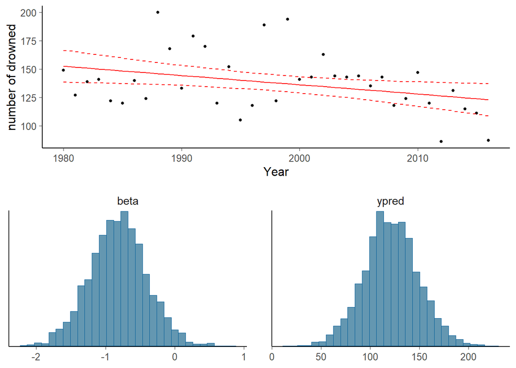

```r
samples_lin <- rstan::extract(fit_lin, permuted = T)
# mean(samples_lin$beta>0) # probability that beta > 0

mu <- apply(samples_lin$mu, 2, quantile, c(0.05, 0.5, 0.95)) %>%
  t() %>% data.frame(x = d_lin$x, .)  %>% gather(pct, y, -x)

pfit <- ggplot() +
  geom_point(aes(x, y), data = data.frame(d_lin), size = 1) +
  geom_line(aes(x, y, linetype = pct), data = mu, color = 'red') +
  scale_linetype_manual(values = c(2,1,2)) +
  labs(y = 'number of drowned', x= "Year") +
  guides(linetype = F)
pars <- intersect(names(samples_lin), c('beta','ypred'))
draws <- as.data.frame(fit_lin)
phist <- mcmc_hist(draws, pars = pars)
grid.arrange(pfit, phist, nrow = 2)
```

As it can be seen the histagrams for posterior beta and posterior predictive for year 2019 match the plots provided in the exercise.

## Seperated Gaussian Model

First we consider the separated model. For this model, each machine j is assumed to have unrelated means $\mu_j$ and $\sigma_j$ and the posterior distribution is determined as follows: $y_j \sim \mathcal{N}(\mu_j, \sigma^2)$. The Stan implementation is as follows:

```r
data("factory")
writeLines(readLines("Assignment7b_separat.stan"))
```

```
##
## data {
##   int<lower=0> N; // number of data points
##   int<lower=0> K; // number of groups
##   int<lower=1,upper=K> x[N]; // group indicator
##   vector[N] y; //
## }
## parameters {
##   vector[K] mu; // group means
##   vector<lower=0>[K] sigma; // group stds
##   real mu_7; // mu for machine 7
##   real <lower=0> s_7; // std for machine 7
## }
## model {
##   y ~ normal(mu[x], sigma[x]);
## }
## generated quantities {
##   real ypred;
##   ypred = normal_rng(mu[6], sigma[6]);
## }
```

The data related to this model is :

```r
data_separate <-list(N = 6*nrow(factory),
                     K = 6,
                     x = rep(1:6, nrow(factory)),
                     y = c(t(factory)))
```

We fit the separate model in stan as follow:

```r
fit_sep <- stan(file="Assignment7b_separat.stan", data = data_separate, seed = SEED)
```

## i) The posterior of the mean of the sixth machine:

$$p(\mu_6|\sigma_6,y_6) \propto \mathcal{N}(\mu_6, \sigma_6^2)$$

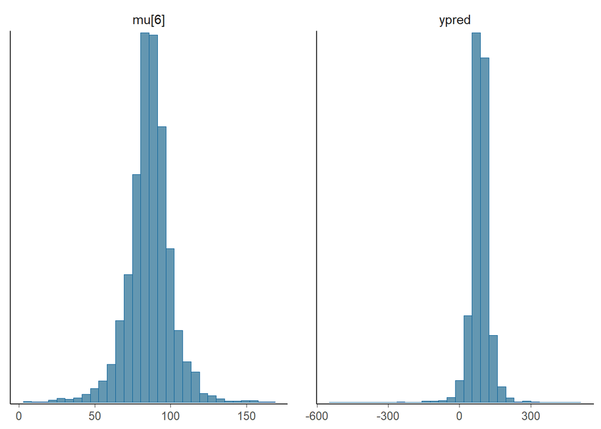

```r
draws_separate <- as.data.frame(fit_sep)
mcmc_hist(draws_separate, pars = c("mu[6]", "ypred"))
```

## ii) The predictive distribution for another quality measurement from the sixth machine:

$$p(\hat{y_6}|\mu,\sigma) \propto \mathcal{N}(\mu_6, \sigma_6^2)$$

## iii) The posterior distribution of the mean of the quality measurements of the seventh machine:

Since the machine is completely separate from the others, we cannot infer anything about the model from the posteriors of the other machines. Therefore the best prediction for $\mu_7$ is the prior, which is in this case poorly defined, since we are using the uninformative uniform priors.

## Pooled model

For the pooled model we assume that $\mu$ and $\sigma$ are the same for all machines. The Stan implementation for pooled model is as:

```r
writeLines(readLines("Assignment7b_pooled.stan"))
```

```
##
## data {
##   int<lower=0> N; // number of data points
##   vector[N] y; //
## }
## parameters {
##   real mu; // group means
##   real<lower=0> sigma; // common std
##   // real mu0; // prior mean
##   // real<lower=0> musigma0; // prior std
##   // real mu_7; // mu value for machine 7
## }
## model {
##   // mu0 ~ normal(10, 10); // weakly informative prior
##   // sigma0 ~ cauchy(0,10); // weakly informative prior
##   // mu ~ normal(mu0, sigma0); // population prior with unknown parameters
##   // sigma ~ cauchy(0,4); // weakly informative prior
##   // for(i in 1:N) {
##   //   y[i] ~ normal(mu, sigma);
##   // }
##   // mu_7 ~ normal(mu0, sigma0);
##   y ~ normal(mu, sigma);
## }
## generated quantities {
##   real ypred;
##   real mu_7;
##   ypred = normal_rng(mu, sigma);
##   mu_7 = normal_rng(mu, sigma);
## }
```

The data related to this model is :

```r
data_pooled <- list(N = 6*nrow(factory),
                    y = c(t(factory)))
```

We fit the pooled model in stan as follows:

```r
fit_pooled <- stan(file = "Assignment7b_pooled.stan", data = data_pooled, seed = SEED)
```

## i) The posterior of the mean of the sixth machine:

$$p(\mu|\sigma, y) \propto \mathcal{N}(\mu, \sigma^2)$$

## ii) The predictive distribution for another quality measurement from the sixth machine:

$$p(\hat{y_6}|\mu,\sigma) \propto \mathcal{N}(\mu, \sigma^2)$$

## iii) The posterior distribution of the mean of the quality measurements of the seventh machine:

Since the machines are assumed to be identical, the posterior distribution of the mean of the seventh machine is given as:
$$p(\mu_7|\mu, \sigma) \propto \mathcal{N}(\mu, \sigma^2)$$

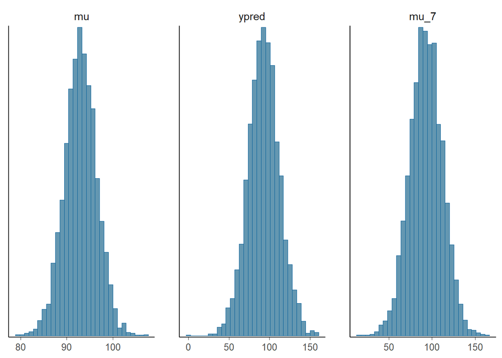

```r
draws_pooled <- as.data.frame(fit_pooled)
mcmc_hist(draws_pooled, pars = c("mu", "ypred", "mu_7"))
```

## Hierarchical model

In this model the means of the different machines are assumed to have a common standard deviation $\sigma$ and means $\mu$ that are drawn from a normal distribution with $\mu_0$ and $\sigma_0$. The Stan implementation of the model is as follows:

```r
writeLines(readLines("Assignment7b_hierarchical.stan"))
```

```
## data {
##   int<lower=0> N; // number of data points
##   int<lower=0> K; // number of groups
##   int<lower=1,upper=K> x[N]; // group indicator
##   vector[N] y; //
## }
## parameters {
##   real mu0; // prior mean
##   real<lower=0> sigma0; // prior std
##   vector[K] mu; // group means
##   real<lower=0> sigma; // group stds
## }
## model {
##   mu0 ~ normal(50, 10); // weakly informative prior
##   sigma0 ~ cauchy(0,4); // weakly informative prior
##   mu ~ normal(mu0, sigma0); // population prior with unknown parameters
##   sigma ~ cauchy(0,4); // weakly informative prior
##   y ~ normal(mu[x] , sigma);
## }
## generated quantities {
##   real ypred;
##   real mu_7;
##   ypred = normal_rng(mu[6], sigma);
##   mu_7 = normal_rng(mu0, sigma);
## }
```

```r
fit_hierarchical <- stan(file="Assignment7b_hierarchical.stan", data = data_separate, seed = SEED)
```

## i) The posterior of the mean of the sixth machine:

## ii) The predictive distribution for another quality measurement from the sixth machine:

$$p(\hat{y_6}|\mu,\sigma) \propto \mathcal{N}(\mu_6, \sigma_6^2)$$

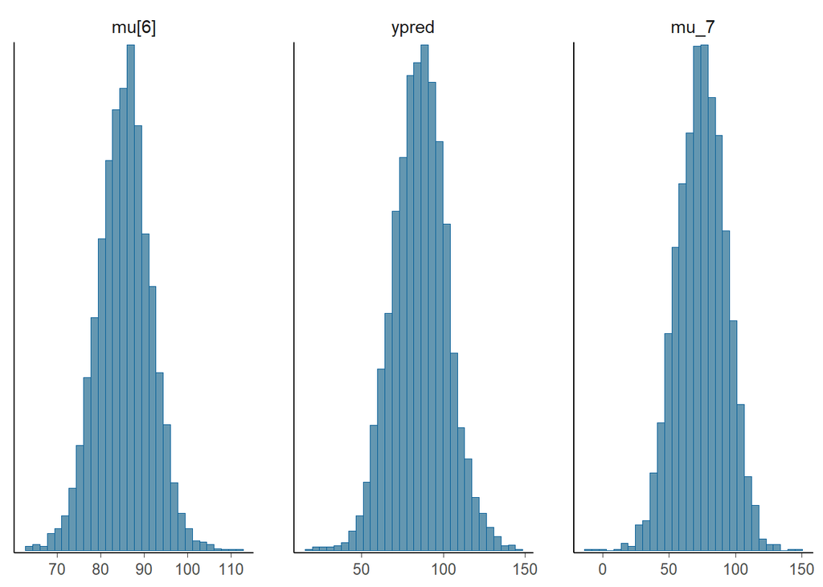

```r
draws_hierarchical <- as.data.frame(fit_hierarchical)
mcmc_hist(draws_hierarchical, c("mu[6]", "ypred", "mu_7"))
```